# Praca domowa 5 - MIOWAD

```python
import pandas as pd
import numpy as np
import matplotlib.pyplot as plt
```

```python
from NeuralNetwork.NeuralNetwork import *
from NeuralNetwork.Layers import *
from NeuralNetwork.ActivationFunctions import *
from NeuralNetwork.Initializers import *
from NeuralNetwork.Optimizers import *
```

## Zbiór multimodal-large

```python
df = pd.read_csv("./data/regression/multimodal-large-training.csv")
X = df.x.to_numpy()
X = np.transpose(np.array([X]))
Y = df.y.to_numpy()
Y = np.transpose(np.array([Y]))

df1 = pd.read_csv("./data/regression/multimodal-large-test.csv")
X1 = df1.x.to_numpy()
X1 = np.transpose(np.array([X1]))
Y1 = df1.y.to_numpy()
Y1 = np.transpose(np.array([Y1]))
```

### Funkcja aktywacji sigmoid

Jedna warstwa ukryta

```python
np.random.seed(0)
n1_m1 = Net(optimizer = GradientDescentBatch_Momentum(learning_rate=0.00001, batch_size=64, momentum = 0.3))
n1_m1.add_layer(DenseNetLayer(1, 20, SigmoidFunction(), RandomNormalInitializer()))
n1_m1.add_layer(DenseNetLayer(20, 1, LinearFunction(), RandomNormalInitializer()))
n1_m1.train(X, Y, X1, Y1, n_epochs=500, eval_frequency=100)
```

```
Epoch: 0, mse train: 4671.5859993908725, mse eval: 4706.282432288104
Epoch: 100, mse train: 3103.552528551239, mse eval: 3151.9818594578646
Epoch: 200, mse train: 3024.8112285533866, mse eval: 3079.4507892882602
Epoch: 300, mse train: 3143.3109145013614, mse eval: 3203.694178635359
Epoch: 400, mse train: 3001.36719640873, mse eval: 3061.976675869453
Training result:
    mse train: 2968.9046862316613
    mse eval: 3030.4288823912293
```

Dwie warstwy ukryta

```python
np.random.seed(0)
n1_m2 = Net(optimizer = GradientDescentBatch_Momentum(learning_rate=0.00001, batch_size=64, momentum = 0.3))
n1_m2.add_layer(DenseNetLayer(1, 20, SigmoidFunction(), RandomNormalInitializer()))
n1_m2.add_layer(DenseNetLayer(20, 5, SigmoidFunction(), RandomNormalInitializer()))
n1_m2.add_layer(DenseNetLayer(5, 1, LinearFunction(), RandomNormalInitializer()))
n1_m2.train(X, Y, X1, Y1, n_epochs=500, eval_frequency=100)
```

```
Epoch: 0, mse train: 5042.275301625854, mse eval: 5085.344586813099
Epoch: 100, mse train: 364.10680491383204, mse eval: 403.4060236417274
Epoch: 200, mse train: 175.80785711524203, mse eval: 186.16527319693083
Epoch: 300, mse train: 38.632557282875176, mse eval: 39.55188784139392
Epoch: 400, mse train: 14.911575634694103, mse eval: 11.29381080595377
Training result:
    mse train: 13.182717598943846
    mse eval: 8.888918325036837
```

Trzy warstwy ukryta

```python
np.random.seed(0)
n1_m3 = Net(optimizer = GradientDescentBatch_Momentum(learning_rate=0.00001, batch_size=64, momentum = 0.3))
n1_m3.add_layer(DenseNetLayer(1, 20, SigmoidFunction(), RandomNormalInitializer()))
n1_m3.add_layer(DenseNetLayer(20, 20, SigmoidFunction(), RandomNormalInitializer()))
n1_m3.add_layer(DenseNetLayer(20, 5, SigmoidFunction(), RandomNormalInitializer()))
n1_m3.add_layer(DenseNetLayer(5, 1, LinearFunction(), RandomNormalInitializer()))
n1_m3.train(X, Y, X1, Y1, n_epochs=500, eval_frequency=100)
```

```
Epoch: 0, mse train: 5200.630321059154, mse eval: 5247.96320775338
Epoch: 100, mse train: 11.101610501502673, mse eval: 7.193694562166014
Epoch: 200, mse train: 8.641646973087525, mse eval: 4.79036812500372
Epoch: 300, mse train: 7.265426761300217, mse eval: 3.4183036892112737
Epoch: 400, mse train: 6.737587792169719, mse eval: 2.948822375937938
Training result:
    mse train: 6.371597574088082
    mse eval: 2.664295411150967
```

### Funkcja aktywacji ReLU

Jedna warstwa ukryta

```python
np.random.seed(0)
n1_m5_11 = Net(optimizer = GradientDescentBatch_Momentum(learning_rate=0.00001, batch_size=64, momentum = 0.3))
n1_m5_11.add_layer(DenseNetLayer(1, 50, ReLU(), RandomNormalInitializer()))
n1_m5_11.add_layer(DenseNetLayer(50, 1, LinearFunction(), RandomNormalInitializer()))
n1_m5_11.train(X, Y, X1, Y1, n_epochs=500, eval_frequency=100)
```

```
Epoch: 0, mse train: 3693.2863438842887, mse eval: 3723.538754998679
Epoch: 100, mse train: 2582.795968048793, mse eval: 2597.814320759939
Epoch: 200, mse train: 2590.0486953609575, mse eval: 2604.6910453054243
Epoch: 300, mse train: 2635.246125924731, mse eval: 2648.948770165437
Epoch: 400, mse train: 2695.1192211015864, mse eval: 2708.6509204917
Training result:
    mse train: 2833.7018613998516
    mse eval: 2847.4108305804916
```

Dwie warstwy ukryte

```python
np.random.seed(0)
n1_m5_1 = Net(optimizer = GradientDescentBatch_Momentum(learning_rate=0.00001, batch_size=64, momentum = 0.3))
n1_m5_1.add_layer(DenseNetLayer(1, 50, ReLU(), RandomNormalInitializer()))
n1_m5_1.add_layer(DenseNetLayer(50, 20, ReLU(), RandomNormalInitializer()))
n1_m5_1.add_layer(DenseNetLayer(20, 1, LinearFunction(), RandomNormalInitializer()))
n1_m5_1.train(X, Y, X1, Y1, n_epochs=500, eval_frequency=100)
```

```
Epoch: 0, mse train: 1970.217467947542, mse eval: 1990.704410644809
Epoch: 100, mse train: 85.47829367557154, mse eval: 87.62234738761057
Epoch: 200, mse train: 23.119055643339728, mse eval: 18.459679130009324
Epoch: 300, mse train: 19.88328827320891, mse eval: 15.119899500475464
Epoch: 400, mse train: 19.48539726230096, mse eval: 14.848003466972154
Training result:
    mse train: 19.970279795963748
    mse eval: 15.41226135882491
```

Trzy warstwy ukryte

```python
np.random.seed(0)
n1_m6_1 = Net(optimizer = GradientDescentBatch_Momentum(learning_rate=0.000001, batch_size=64, momentum = 0.3))
n1_m6_1.add_layer(DenseNetLayer(1, 50, ReLU(), RandomNormalInitializer()))
n1_m6_1.add_layer(DenseNetLayer(50, 50, ReLU(), RandomNormalInitializer()))
n1_m6_1.add_layer(DenseNetLayer(50, 20, ReLU(), RandomNormalInitializer()))
n1_m6_1.add_layer(DenseNetLayer(20, 1, LinearFunction(), RandomNormalInitializer()))
n1_m6_1.train(X, Y, X1, Y1, n_epochs=500, eval_frequency=100)
```

```
Epoch: 0, mse train: 1027.4954605240457, mse eval: 1063.232324294943
Epoch: 100, mse train: 61.00832638268088, mse eval: 54.516830145192436
Epoch: 200, mse train: 23.237308728850813, mse eval: 19.097718062307795
```

[output not shown]

Kod zatrzymany ze względu na zadowalający wynik i długi czas uczenia

### Funkcja aktywacji Tanh

Jedna warstwa ukryta

```python
np.random.seed(0)
n1_m8 = Net(optimizer = GradientDescentBatch_Momentum(learning_rate=0.00001, batch_size=64, momentum = 0.3))
n1_m8.add_layer(DenseNetLayer(1, 20, Tanh(), RandomNormalInitializer()))
n1_m8.add_layer(DenseNetLayer(20, 1, LinearFunction(), RandomNormalInitializer()))
n1_m8.train(X, Y, X1, Y1, n_epochs=500, eval_frequency=100)
```

```
Epoch: 0, mse train: 3929.369837234184, mse eval: 3957.0315721267225
Epoch: 100, mse train: 2920.081347355258, mse eval: 2988.9910674637918
Epoch: 200, mse train: 2897.4670195131093, mse eval: 2969.145377061928
Epoch: 300, mse train: 2886.4138549996583, mse eval: 2959.405031711002
Epoch: 400, mse train: 2879.342146711248, mse eval: 2953.1631400263554
Training result:
    mse train: 2874.287314204313
    mse eval: 2948.6983175711725
```

Dwie warstwy ukryte

```python
np.random.seed(0)
n1_m9 = Net(optimizer = GradientDescentBatch_Momentum(learning_rate=0.00001, batch_size=64, momentum = 0.3))
n1_m9.add_layer(DenseNetLayer(1, 20, Tanh(), RandomNormalInitializer()))
n1_m9.add_layer(DenseNetLayer(20, 20, Tanh(), RandomNormalInitializer()))
n1_m9.add_layer(DenseNetLayer(20, 1, LinearFunction(), RandomNormalInitializer()))
n1_m9.train(X, Y, X1, Y1, n_epochs=500, eval_frequency=100)
```

```
Epoch: 0, mse train: 1774.7797144516633, mse eval: 1800.5843971483923
Epoch: 100, mse train: 8.543808492778151, mse eval: 4.378695364386424
Epoch: 200, mse train: 6.818833322965847, mse eval: 2.0646165785943067
Epoch: 300, mse train: 6.662155435083342, mse eval: 1.8724053720373237
Epoch: 400, mse train: 6.615527339852022, mse eval: 1.8144326190388247
Training result:
    mse train: 6.593267254395758
    mse eval: 1.7858639997007049
```

Trzy warstwy ukryte

```python
np.random.seed(0)
n1_m10 = Net(optimizer = GradientDescentBatch_Momentum(learning_rate=0.00001, batch_size=64, momentum = 0.3))
n1_m10.add_layer(DenseNetLayer(1, 20, Tanh(), RandomNormalInitializer()))
n1_m10.add_layer(DenseNetLayer(20, 20, Tanh(), RandomNormalInitializer()))
n1_m10.add_layer(DenseNetLayer(20, 20, Tanh(), RandomNormalInitializer()))
n1_m10.add_layer(DenseNetLayer(20, 1, LinearFunction(), RandomNormalInitializer()))
n1_m10.train(X, Y, X1, Y1, n_epochs=500, eval_frequency=100)
```

```
Epoch: 0, mse train: 768.6689853656001, mse eval: 793.7538416512142
Epoch: 100, mse train: 288.139091971162, mse eval: 319.7355704715034
Epoch: 200, mse train: 9.409677738746945, mse eval: 5.428843985253996
Epoch: 300, mse train: 3.636384639753422, mse eval: 1.4703824679146937
Epoch: 400, mse train: 3.5969009613697183, mse eval: 1.527710144557699
Training result:
    mse train: 3.2576061817559117
    mse eval: 1.3623626092044632
```

### Funkcja aktywacji liniowa

Jedna warstwa ukryta

```python
np.random.seed(0)
n1_m11 = Net(optimizer = GradientDescentBatch_Momentum(learning_rate=0.00001, batch_size=64, momentum = 0.3))
n1_m11.add_layer(DenseNetLayer(1, 20, LinearFunction(), RandomNormalInitializer()))
n1_m11.add_layer(DenseNetLayer(20, 1, LinearFunction(), RandomNormalInitializer()))
n1_m11.train(X, Y, X1, Y1, n_epochs=500, eval_frequency=100)
```

```
Epoch: 0, mse train: 4398.347185631703, mse eval: 4434.0053161432825
Epoch: 100, mse train: 4398.305788624023, mse eval: 4433.934205160814
Epoch: 200, mse train: 4398.302953147226, mse eval: 4433.933263536987
Epoch: 300, mse train: 4398.301809119413, mse eval: 4433.93205812946
Epoch: 400, mse train: 4398.300354308789, mse eval: 4433.928665142586
Training result:
    mse train: 4398.298725456275
    mse eval: 4433.924219130352
```

Dwie warstwy ukryte

```python
np.random.seed(0)
n1_m12 = Net(optimizer = GradientDescentBatch_Momentum(learning_rate=0.00001, batch_size=64, momentum = 0.3))
n1_m12.add_layer(DenseNetLayer(1, 20, LinearFunction(), RandomNormalInitializer()))
n1_m12.add_layer(DenseNetLayer(20, 20, LinearFunction(), RandomNormalInitializer()))
n1_m12.add_layer(DenseNetLayer(20, 1, LinearFunction(), RandomNormalInitializer()))
n1_m12.train(X, Y, X1, Y1, n_epochs=500, eval_frequency=100)
```

```
Epoch: 0, mse train: 4399.379464142801, mse eval: 4435.108412248007
Epoch: 100, mse train: 4398.228772967685, mse eval: 4433.763602253603
Epoch: 200, mse train: 4398.233243527745, mse eval: 4433.780559014788
Epoch: 300, mse train: 4398.23688673157, mse eval: 4433.792116090395
Epoch: 400, mse train: 4398.239950190738, mse eval: 4433.800506383389
Training result:
    mse train: 4398.242635655264
    mse eval: 4433.807062189901
```

Trzy warstwy ukryte

```python
np.random.seed(0)
n1_m13 = Net(optimizer = GradientDescentBatch_Momentum(learning_rate=0.000001, batch_size=64, momentum = 0.3))
n1_m13.add_layer(DenseNetLayer(1, 20, LinearFunction(), RandomNormalInitializer()))
n1_m13.add_layer(DenseNetLayer(20, 20, LinearFunction(), RandomNormalInitializer()))
n1_m13.add_layer(DenseNetLayer(20, 20, LinearFunction(), RandomNormalInitializer()))
n1_m13.add_layer(DenseNetLayer(20, 1, LinearFunction(), RandomNormalInitializer()))
n1_m13.train(X, Y, X1, Y1, n_epochs=100, eval_frequency=10)
```

```
Epoch: 0, mse train: 4402.253191868307, mse eval: 4438.3421658037305
Epoch: 10, mse train: 4398.6145111269925, mse eval: 4434.510332728127
Epoch: 20, mse train: 4398.387302887825, mse eval: 4434.169232392577
Epoch: 30, mse train: 4398.346254594459, mse eval: 4434.065511174535
Epoch: 40, mse train: 4398.339732516556, mse eval: 4434.0222418261665
Epoch: 50, mse train: 4398.342270748291, mse eval: 4434.002894555958
Epoch: 60, mse train: 4398.346715465972, mse eval: 4433.994491583011
Epoch: 70, mse train: 4398.35075497472, mse eval: 4433.991409483369
Epoch: 80, mse train: 4398.353703396512, mse eval: 4433.990950874013
Epoch: 90, mse train: 4398.355495409819, mse eval: 4433.991755870768
Training result:
    mse train: 4398.356259510806
    mse eval: 4433.992972817635
```

## Zbiór steps-large

```python
df = pd.read_csv("./data/regression/steps-large-training.csv", index_col=0)
X = df.x.to_numpy()
X = np.transpose(np.array([X]))
Y = df.y.to_numpy()
Y = np.transpose(np.array([Y]))

df1 = pd.read_csv("./data/regression/steps-large-test.csv", index_col=0)
X1 = df1.x.to_numpy()
X1 = np.transpose(np.array([X1]))
Y1 = df1.y.to_numpy()
Y1 = np.transpose(np.array([Y1]))
```

### Funkcja aktywacji liniowa

```python
np.random.seed(0)
n3 = Net(optimizer = SGD_Momentum(learning_rate=0.00001, momentum=0.8))
n3.add_layer(DenseNetLayer(1, 20, LinearFunction(), RandomNormalInitializer()))
n3.add_layer(DenseNetLayer(20, 20, LinearFunction(), RandomNormalInitializer()))
n3.add_layer(DenseNetLayer(20, 10, LinearFunction(), RandomNormalInitializer()))
n3.add_layer(DenseNetLayer(10, 1, LinearFunction(), RandomNormalInitializer()))
n3.train(X, Y, X1, Y1, n_epochs=500, eval_frequency=50)
```

```
Epoch: 0, mse train: 525.2914905192612, mse eval: 538.5382206686611
Epoch: 50, mse train: 525.402105429258, mse eval: 537.4075759070395
Epoch: 100, mse train: 525.6531059103871, mse eval: 537.6170829912094
Epoch: 150, mse train: 525.7973811547135, mse eval: 537.7393293663038
Epoch: 200, mse train: 525.898015323886, mse eval: 537.8257403001923
Epoch: 250, mse train: 525.9729546625131, mse eval: 537.889799185952
Epoch: 300, mse train: 526.0313409235554, mse eval: 537.9389756919601
Epoch: 350, mse train: 526.0785575137684, mse eval: 537.9779796937161
Epoch: 400, mse train: 526.1179699419712, mse eval: 538.0098849168994
Epoch: 450, mse train: 526.1517649793633, mse eval: 538.036740103442
Training result:
    mse train: 526.1808449187765
    mse eval: 538.0594977523641
```

```python
np.random.seed(0)
n3_1 = Net(optimizer = SGD(learning_rate=0.00001))
n3_1.add_layer(DenseNetLayer(1, 20, LinearFunction(), RandomNormalInitializer()))
n3_1.add_layer(DenseNetLayer(20, 20, LinearFunction(), RandomNormalInitializer()))
n3_1.add_layer(DenseNetLayer(20, 10, LinearFunction(), RandomNormalInitializer()))
n3_1.add_layer(DenseNetLayer(10, 1, LinearFunction(), RandomNormalInitializer()))
n3_1.train(X, Y, X1, Y1, n_epochs=500, eval_frequency=50)
```

```
Epoch: 0, mse train: 518.2961958284134, mse eval: 529.4974619789848
Epoch: 50, mse train: 519.2884920230442, mse eval: 529.9085440684904
Epoch: 100, mse train: 519.2844750266828, mse eval: 529.9143119553821
Epoch: 150, mse train: 519.2801250092285, mse eval: 529.9215739544319
Epoch: 200, mse train: 519.2807730842189, mse eval: 529.9254680026164
Epoch: 250, mse train: 519.2802992357708, mse eval: 529.9252596588587
Epoch: 300, mse train: 519.2787261629196, mse eval: 529.9233432965821
Epoch: 350, mse train: 519.2767507129618, mse eval: 529.920797630624
Epoch: 400, mse train: 519.274703812347, mse eval: 529.9180368799045
Epoch: 450, mse train: 519.2727036099642, mse eval: 529.9152335770149
Training result:
    mse train: 519.2708259353578
    mse eval: 529.9125226184684
```

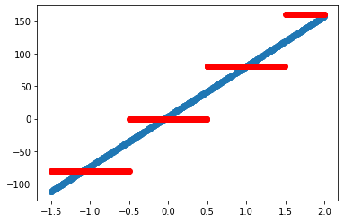

```python
plt.scatter(X1, n3_1.forward(X1))
plt.scatter(X1, Y1, color='red')
plt.show()
```

### Funkcja aktywacji Tanh

```python
np.random.seed(0)
n3_2 = Net(optimizer = SGD(learning_rate=0.00001))
n3_2.add_layer(DenseNetLayer(1, 20, Tanh(), RandomNormalInitializer()))
n3_2.add_layer(DenseNetLayer(20, 20, Tanh(), RandomNormalInitializer()))
n3_2.add_layer(DenseNetLayer(20, 10, Tanh(), RandomNormalInitializer()))
n3_2.add_layer(DenseNetLayer(10, 1, LinearFunction(), RandomNormalInitializer()))
n3_2.train(X, Y, X1, Y1, n_epochs=500, eval_frequency=50)
```

```
Epoch: 0, mse train: 665.5756191147563, mse eval: 683.617594678004
Epoch: 50, mse train: 51.05304581457259, mse eval: 68.11269999950748
Epoch: 100, mse train: 41.775255688352104, mse eval: 23.945472953194695
Epoch: 150, mse train: 50.57109083593794, mse eval: 28.267556612367756
Epoch: 200, mse train: 28.05149536410435, mse eval: 25.339130172583655
Epoch: 250, mse train: 53.881527569559296, mse eval: 28.439107720170693
Epoch: 300, mse train: 40.302148364234625, mse eval: 20.49529132239522
Epoch: 350, mse train: 13.153576962705158, mse eval: 9.364188294168809
Epoch: 400, mse train: 32.0307134055936, mse eval: 36.20790403997217
Epoch: 450, mse train: 17.830079709839342, mse eval: 8.745363020751787
Training result:
    mse train: 83.03367529132768
    mse eval: 54.8351242364684
```

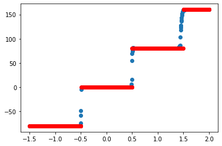

```python
plt.scatter(X1, n3_2.forward(X1))
plt.scatter(X1, Y1, color='red')
plt.show()
```

## Zbiór rings3-regular

```python
df = pd.read_csv("./data/classification/rings3-regular-training.csv")
X = df[['x', 'y']].to_numpy()
Y = pd.get_dummies(df.c).to_numpy()

df1 = pd.read_csv("./data/classification/rings3-regular-test.csv")
X1 = df1[['x', 'y']].to_numpy()
Y1 = pd.get_dummies(df1.c).to_numpy()
```

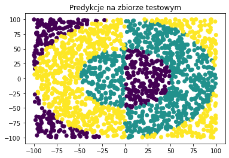

```python
plt.scatter(X1[:, 0], X1[:, 1], c = df1.c)
plt.title('Predykcje na zbiorze testowym')
plt.show()
```

```python
# Funkcja do "wyciągania" predykcji z outputu z softmaxa

def p(x):
    t = x.argmax()
    out = np.zeros_like(x)
    out[t] = 1
    return out
```

### Funkcja aktywacji Tanh

```python
np.random.seed(0)
n2_m6 = Net(optimizer = GradientDescentBatch(learning_rate=0.0001, batch_size=128), loss = 'cross-entropy')
n2_m6.add_layer(DenseNetLayer(2, 20, Tanh(), XavierInitializer(2, 20)))
n2_m6.add_layer(DenseNetLayer(20, 20, Tanh(), XavierInitializer(20, 20)))
n2_m6.add_layer(DenseNetLayer(20, 5, Tanh(), XavierInitializer(20, 5)))
n2_m6.add_layer(DenseNetLayer(5, 3, SoftmaxAsLastLayerWithCrossEntropy(), XavierInitializer(5, 3)))
n2_m6.train(X, Y, X1, Y1, n_epochs=500, eval_frequency=100)
```

```
Epoch: 0, cross-entropy train: 1.347598459368806, cross-entropy eval: 1.2772013602642271
Epoch: 100, cross-entropy train: 0.9904211613585452, cross-entropy eval: 0.9573909663025025
Epoch: 200, cross-entropy train: 1.0339056403591904, cross-entropy eval: 0.9975908940409023
Epoch: 300, cross-entropy train: 0.9771186779915323, cross-entropy eval: 0.9520983647221857
Epoch: 400, cross-entropy train: 0.9682160664421754, cross-entropy eval: 0.9424169869142022
Training result:
    cross-entropy train: 0.9620981361148884
    cross-entropy eval: 0.9354985136397098
```

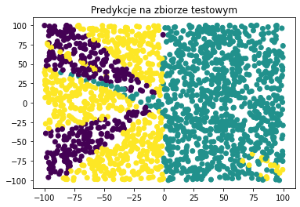

```python
plt.scatter(X1[:, 0], X1[:, 1], c = np.apply_along_axis(p, 1, n2_m6.forward(X1)).argmax(axis=1))
plt.title('Predykcje na zbiorze testowym')
plt.show()
```

```python
n2_m6.train(X, Y, X1, Y1, n_epochs=100, eval_frequency=50)
```

```
Epoch: 0, cross-entropy train: 0.9101710134523913, cross-entropy eval: 0.8959047724335467
Epoch: 50, cross-entropy train: 0.892308500010525, cross-entropy eval: 0.8811863957186489
Training result:
    cross-entropy train: 0.8725823748290645
    cross-entropy eval: 0.8639113276842912
```

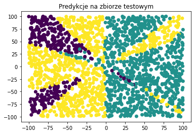

```python
plt.scatter(X1[:, 0], X1[:, 1], c = np.apply_along_axis(p, 1, n2_m6.forward(X1)).argmax(axis=1))
plt.title('Predykcje na zbiorze testowym')
plt.show()
```

```python
print(f"F1-score-macro na zbiorze testowym wynosi: {f1_score_macro(Y1, np.apply_along_axis(p, 1, n2_m6.forward(X1)))}")
```

```
F1-score-macro na zbiorze testowym wynosi: 0.5592346306904242
```

```python
import copy

n2_m6_copy = copy.deepcopy(n2_m6)
```

```python
n2_m6_copy.train(X, Y, X1, Y1, n_epochs=500, eval_frequency=100)
```

```
Epoch: 0, cross-entropy train: 0.9101710134523913, cross-entropy eval: 0.8959047724335467
Epoch: 100, cross-entropy train: 0.8737899053656107, cross-entropy eval: 0.8649892009939751
Epoch: 200, cross-entropy train: 0.9435647533883141, cross-entropy eval: 0.926499429242577
Epoch: 300, cross-entropy train: 0.9348141887609664, cross-entropy eval: 0.9263526528536762
Epoch: 400, cross-entropy train: 0.9323954205540158, cross-entropy eval: 0.9158793755149494
Training result:
    cross-entropy train: 0.9456293239971444
    cross-entropy eval: 0.922216625150319
```

```python
n2_m6_copy.train(X, Y, X1, Y1, n_epochs=500, eval_frequency=100)
```

```
Epoch: 0, cross-entropy train: 0.9454151954368306, cross-entropy eval: 0.9221049057983568
Epoch: 100, cross-entropy train: 0.9221386141610198, cross-entropy eval: 0.9060983638538102
Epoch: 200, cross-entropy train: 0.9200604080642286, cross-entropy eval: 0.9019865460345706
Epoch: 300, cross-entropy train: 0.8510707530186096, cross-entropy eval: 0.8263713986626363
Epoch: 400, cross-entropy train: 0.8566271719046656, cross-entropy eval: 0.8294632288255771
Training result:
    cross-entropy train: 0.8403337222179895
    cross-entropy eval: 0.8086959209597038
```

```python
n2_m6_copy.train(X, Y, X1, Y1, n_epochs=500, eval_frequency=100)
```

```
Epoch: 0, cross-entropy train: 0.841484612409489, cross-entropy eval: 0.8100776297658797
Epoch: 100, cross-entropy train: 0.8890263968337717, cross-entropy eval: 0.8415734256783187
Epoch: 200, cross-entropy train: 0.9951148521298238, cross-entropy eval: 0.953795919487378
Epoch: 300, cross-entropy train: 0.9534795017511076, cross-entropy eval: 0.9485431236321566
Epoch: 400, cross-entropy train: 0.9452927758291809, cross-entropy eval: 0.9372545342795754
Training result:
    cross-entropy train: 0.9572527770449785
    cross-entropy eval: 0.9418556755314591
```

Dalsze trenowanie nie doprowadza do zmniejszenia wartości funkcji straty

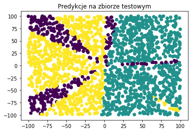

```python
plt.scatter(X1[:, 0], X1[:, 1], c = np.apply_along_axis(p, 1, n2_m6_copy.forward(X1)).argmax(axis=1))
plt.title('Predykcje na zbiorze testowym')
plt.show()
```

```python
print(f"F1-score-macro na zbiorze testowym wynosi: {f1_score_macro(Y1, np.apply_along_axis(p, 1, n2_m6_copy.forward(X1)))}")
```

```
F1-score-macro na zbiorze testowym wynosi: 0.5569190158200514
```

### Funkcja aktywacji ReLU

Architektury z jedną, dwiema i trzema warstwami ukrytymi nie dawały dobrych rezultatów - dopiero sieć z czteroma wartswami ukrytymi dość dobrze rozwiązała problem.

```python
np.random.seed(0)
n2 = Net(optimizer = GradientDescentBatch(learning_rate=0.0001, batch_size=128), loss = 'cross-entropy')
n2.add_layer(DenseNetLayer(2, 20, ReLU(), XavierInitializer(2, 20)))
n2.add_layer(DenseNetLayer(20, 20, ReLU(), XavierInitializer(20, 20)))
n2.add_layer(DenseNetLayer(20, 20, ReLU(), XavierInitializer(20, 20)))
n2.add_layer(DenseNetLayer(20, 20, ReLU(), XavierInitializer(20, 20)))
n2.add_layer(DenseNetLayer(20, 3, SoftmaxAsLastLayerWithCrossEntropy(), XavierInitializer(20, 3)))
```

```python
n2.train(X, Y, X1, Y1, n_epochs=500, eval_frequency=10)
```

```
Epoch: 0, cross-entropy train: 4.656560742823083, cross-entropy eval: 3.591081225437308
Epoch: 10, cross-entropy train: 0.9679498065860473, cross-entropy eval: 0.9058866900553851
Epoch: 20, cross-entropy train: 0.9022761134056122, cross-entropy eval: 0.8522503258352528
Epoch: 30, cross-entropy train: 0.8884136978174588, cross-entropy eval: 0.8438154019361908
Epoch: 40, cross-entropy train: 0.9101570081990806, cross-entropy eval: 0.843239532308475
Epoch: 50, cross-entropy train: 0.8544775539996114, cross-entropy eval: 0.8185112767156713
Epoch: 60, cross-entropy train: 0.8466546572323652, cross-entropy eval: 0.8149215720185278
Epoch: 70, cross-entropy train: 0.8435926015717615, cross-entropy eval: 0.8074208557620269
Epoch: 80, cross-entropy train: 0.8406284781978633, cross-entropy eval: 0.804909522515628
Epoch: 90, cross-entropy train: 0.8381796657612646, cross-entropy eval: 0.8004797001886632
Epoch: 100, cross-entropy train: 0.8348928313423696, cross-entropy eval: 0.7960840693893548
Epoch: 110, cross-entropy train: 0.829363985191148, cross-entropy eval: 0.7931152211537678
Epoch: 120, cross-entropy train: 0.8202442395718553, cross-entropy eval: 0.7871569452253656
Epoch: 130, cross-entropy train: 0.8122224618388576, cross-entropy eval: 0.7809496382206438
Epoch: 140, cross-entropy train: 0.8075680987586518, cross-entropy eval: 0.7748193832758297
Epoch: 150, cross-entropy train: 0.8052810865579934, cross-entropy eval: 0.7707709037938638
Epoch: 160, cross-entropy train: 0.8017837095031505, cross-entropy eval: 0.7653729724424241
Epoch: 170, cross-entropy train: 0.8010345856211263, cross-entropy eval: 0.7640792963523015
Epoch: 180, cross-entropy train: 0.8013189663140077, cross-entropy eval: 0.7638446943028087
Epoch: 190, cross-entropy train: 0.7986492592396558, cross-entropy eval: 0.7594328622630359
Epoch: 200, cross-entropy train: 0.7945492820196454, cross-entropy eval: 0.7542629248281985
Epoch: 210, cross-entropy train: 0.7938318217376835, cross-entropy eval: 0.7518623539671934
Epoch: 220, cross-entropy train: 0.7901935364291011, cross-entropy eval: 0.7477616551846472
Epoch: 230, cross-entropy train: 0.7868529254225909, cross-entropy eval: 0.7444548215437246
Epoch: 240, cross-entropy train: 0.7848239721392739, cross-entropy eval: 0.7414548032653041
Epoch: 250, cross-entropy train: 0.7794972633386872, cross-entropy eval: 0.7362244621422427
Epoch: 260, cross-entropy train: 0.7790124589783874, cross-entropy eval: 0.73517088863293
Epoch: 270, cross-entropy train: 0.7767583867431073, cross-entropy eval: 0.732788091535012
Epoch: 280, cross-entropy train: 0.7762184117758605, cross-entropy eval: 0.7309107414628379
Epoch: 290, cross-entropy train: 0.7757561562672798, cross-entropy eval: 0.7307513324767279
Epoch: 300, cross-entropy train: 0.7731080376292558, cross-entropy eval: 0.7255044001556881
Epoch: 310, cross-entropy train: 0.7696378340002809, cross-entropy eval: 0.7246349477874456
Epoch: 320, cross-entropy train: 0.7659626398642159, cross-entropy eval: 0.7192228210529057
Epoch: 330, cross-entropy train: 0.7631587920555082, cross-entropy eval: 0.7175309797023064
Epoch: 340, cross-entropy train: 0.759992544756576, cross-entropy eval: 0.7149519852309408
Epoch: 350, cross-entropy train: 0.7567375047099675, cross-entropy eval: 0.714137927446054
Epoch: 360, cross-entropy train: 0.7462285342361209, cross-entropy eval: 0.7021110414209544
Epoch: 370, cross-entropy train: 0.7445122038857782, cross-entropy eval: 0.7020141732618146
Epoch: 380, cross-entropy train: 0.7403084823494747, cross-entropy eval: 0.6960087471047072
Epoch: 390, cross-entropy train: 0.7404414336779627, cross-entropy eval: 0.6943407556013154
Epoch: 400, cross-entropy train: 0.7385312169511777, cross-entropy eval: 0.6962990888824867
Epoch: 410, cross-entropy train: 0.7366181372187321, cross-entropy eval: 0.694511692126992
Epoch: 420, cross-entropy train: 0.7391871046124535, cross-entropy eval: 0.6947951406838305
Epoch: 430, cross-entropy train: 0.7401473710727379, cross-entropy eval: 0.6952896443517643
Epoch: 440, cross-entropy train: 0.7357545499629564, cross-entropy eval: 0.6926750903335348
Epoch: 450, cross-entropy train: 0.7341551185825751, cross-entropy eval: 0.6912410296211532
Epoch: 460, cross-entropy train: 0.7288543026633851, cross-entropy eval: 0.6920682253860696
Epoch: 470, cross-entropy train: 0.7243243472314302, cross-entropy eval: 0.68600013473253
Epoch: 480, cross-entropy train: 0.7236475934219313, cross-entropy eval: 0.6833695391179044
Epoch: 490, cross-entropy train: 0.7271976904554911, cross-entropy eval: 0.6849634705392498
Training result:
    cross-entropy train: 0.715248433225535
    cross-entropy eval: 0.682845496291376
```

```python
n2.train(X, Y, X1, Y1, n_epochs=500, eval_frequency=10)
```

```
Epoch: 0, cross-entropy train: 0.7126933877045755, cross-entropy eval: 0.6791477666220918
Epoch: 10, cross-entropy train: 0.7091946814494937, cross-entropy eval: 0.6718087885156676
Epoch: 20, cross-entropy train: 0.7061308895443246, cross-entropy eval: 0.6694028870312342
Epoch: 30, cross-entropy train: 0.6979798936613192, cross-entropy eval: 0.6657560995720938
Epoch: 40, cross-entropy train: 0.6982256094002447, cross-entropy eval: 0.6600841246005906
Epoch: 50, cross-entropy train: 0.6869673812540358, cross-entropy eval: 0.6563036604117145
Epoch: 60, cross-entropy train: 0.6853699007787217, cross-entropy eval: 0.6520434310537234
Epoch: 70, cross-entropy train: 0.6821059195868333, cross-entropy eval: 0.6512564651455548
Epoch: 80, cross-entropy train: 0.6779060543382698, cross-entropy eval: 0.647737893248242
Epoch: 90, cross-entropy train: 0.6668834669336202, cross-entropy eval: 0.6377814838747476
Epoch: 100, cross-entropy train: 0.659882417900558, cross-entropy eval: 0.6338943018273125
Epoch: 110, cross-entropy train: 0.6588592064183725, cross-entropy eval: 0.6276322430842023
Epoch: 120, cross-entropy train: 0.6517597336640563, cross-entropy eval: 0.6214909219385617
Epoch: 130, cross-entropy train: 0.6455130526976907, cross-entropy eval: 0.6146555228175017
Epoch: 140, cross-entropy train: 0.6394929623897789, cross-entropy eval: 0.6096199941495819
Epoch: 150, cross-entropy train: 0.6288769583113414, cross-entropy eval: 0.6018478807386232
Epoch: 160, cross-entropy train: 0.6218697538888356, cross-entropy eval: 0.5962361625235028
Epoch: 170, cross-entropy train: 0.6089326851622747, cross-entropy eval: 0.5868859609007664
Epoch: 180, cross-entropy train: 0.5993949360545061, cross-entropy eval: 0.5767332674735062
Epoch: 190, cross-entropy train: 0.5908333379404753, cross-entropy eval: 0.5671233841892743
Epoch: 200, cross-entropy train: 0.5875965936101178, cross-entropy eval: 0.5654554635325968
Epoch: 210, cross-entropy train: 0.5818074285030255, cross-entropy eval: 0.561919014552581
Epoch: 220, cross-entropy train: 0.5771086213893455, cross-entropy eval: 0.5594331520297012
Epoch: 230, cross-entropy train: 0.5709106344963235, cross-entropy eval: 0.5537040369147646
Epoch: 240, cross-entropy train: 0.5656952940052115, cross-entropy eval: 0.5491052854276531
Epoch: 250, cross-entropy train: 0.5616291643388317, cross-entropy eval: 0.5462568965809272
Epoch: 260, cross-entropy train: 0.5566758488972526, cross-entropy eval: 0.5434503263828497
Epoch: 270, cross-entropy train: 0.5564459308068904, cross-entropy eval: 0.541987594301742
Epoch: 280, cross-entropy train: 0.5507745063617389, cross-entropy eval: 0.5371433094028923
Epoch: 290, cross-entropy train: 0.5459637102775711, cross-entropy eval: 0.534221399279052
Epoch: 300, cross-entropy train: 0.537709722242272, cross-entropy eval: 0.5279596955850399
Epoch: 310, cross-entropy train: 0.5399695601026602, cross-entropy eval: 0.5286774862891536
Epoch: 320, cross-entropy train: 0.5363089129381924, cross-entropy eval: 0.525430351569921
Epoch: 330, cross-entropy train: 0.5323342873687184, cross-entropy eval: 0.5221425754389842
Epoch: 340, cross-entropy train: 0.5265756140889888, cross-entropy eval: 0.5189934768799094
Epoch: 350, cross-entropy train: 0.5293886167799936, cross-entropy eval: 0.5205852034228052
Epoch: 360, cross-entropy train: 0.5219487369101972, cross-entropy eval: 0.5152569299537288
Epoch: 370, cross-entropy train: 0.5173492441406784, cross-entropy eval: 0.5107785712241626
Epoch: 380, cross-entropy train: 0.519750585345252, cross-entropy eval: 0.5127184217028201
Epoch: 390, cross-entropy train: 0.5128713481681781, cross-entropy eval: 0.5077437089026329
Epoch: 400, cross-entropy train: 0.5059446860808479, cross-entropy eval: 0.504393835718151
Epoch: 410, cross-entropy train: 0.5134079607700525, cross-entropy eval: 0.5046896237935647
Epoch: 420, cross-entropy train: 0.5078895008999752, cross-entropy eval: 0.5046876876409151
Epoch: 430, cross-entropy train: 0.49573484170467896, cross-entropy eval: 0.49529606249748864
Epoch: 440, cross-entropy train: 0.48968846449501535, cross-entropy eval: 0.4897114590857045
Epoch: 450, cross-entropy train: 0.48372745047749066, cross-entropy eval: 0.4855357243322696
Epoch: 460, cross-entropy train: 0.48729065279334494, cross-entropy eval: 0.4847544447290701
Epoch: 470, cross-entropy train: 0.4762005041998071, cross-entropy eval: 0.4772153947199318
Epoch: 480, cross-entropy train: 0.4640196606720688, cross-entropy eval: 0.468474723981345
Epoch: 490, cross-entropy train: 0.4751649223773423, cross-entropy eval: 0.4749087160198497
Training result:
    cross-entropy train: 0.4710101303227055
    cross-entropy eval: 0.4707513753223643
```

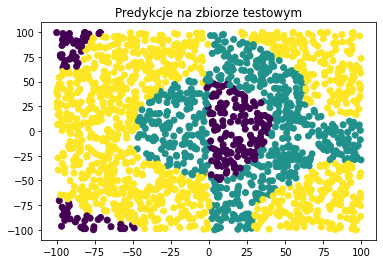

```python
plt.scatter(X1[:, 0], X1[:, 1], c = np.apply_along_axis(p, 1, n2.forward(X1)).argmax(axis=1))
plt.title('Predykcje na zbiorze testowym')
plt.show()
```

```python
print(f"F1-score-macro na zbiorze testowym wynosi: {f1_score_macro(Y1, np.apply_along_axis(p, 1, n2.forward(X1)))}")
```

```
F1-score-macro na zbiorze testowym wynosi: 0.783622642822693
```

## Zbiór rings5-regular

```python
df = pd.read_csv("./data/classification/rings5-regular-training.csv")
X = df[['x', 'y']].to_numpy()
Y = pd.get_dummies(df.c).to_numpy()

df1 = pd.read_csv("./data/classification/rings5-regular-test.csv")
X1 = df1[['x', 'y']].to_numpy()
Y1 = pd.get_dummies(df1.c).to_numpy()
```

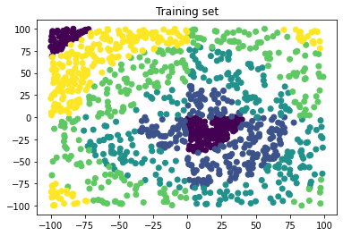

```python
plt.scatter(df.x, df.y, c = df.c)
plt.title('Training set')
plt.show()
```

### Funkcja aktywacji Tanh

```python
np.random.seed(0)
n3_m1 = Net(optimizer = GradientDescentBatch(learning_rate=0.0001, batch_size=64), loss = 'cross-entropy')
n3_m1.add_layer(DenseNetLayer(2, 20, Tanh(), XavierInitializer(2, 20)))
n3_m1.add_layer(DenseNetLayer(20, 20, Tanh(), XavierInitializer(20, 20)))
n3_m1.add_layer(DenseNetLayer(20, 10, Tanh(), XavierInitializer(20, 10)))
n3_m1.add_layer(DenseNetLayer(10, 5, SoftmaxAsLastLayerWithCrossEntropy(), XavierInitializer(10, 5)))
n3_m1.train(X, Y, X1, Y1, n_epochs=500, eval_frequency=100)
```

```
Epoch: 0, cross-entropy train: 1.793547628266901, cross-entropy eval: 1.9208311305750732
Epoch: 100, cross-entropy train: 1.2845708225359562, cross-entropy eval: 1.3968342216136063
Epoch: 200, cross-entropy train: 1.207300417550358, cross-entropy eval: 1.3295785739004093
Epoch: 300, cross-entropy train: 1.1631618324971282, cross-entropy eval: 1.2910278480568842
Epoch: 400, cross-entropy train: 1.1117272664708835, cross-entropy eval: 1.2478958681364754
Training result:
    cross-entropy train: 1.0940047871348373
    cross-entropy eval: 1.2251286755614126
```

```python
n3_m1.train(X, Y, X1, Y1, n_epochs=500, eval_frequency=100)
```

```
Epoch: 0, cross-entropy train: 1.0946060279883323, cross-entropy eval: 1.2256387665385904
Epoch: 100, cross-entropy train: 1.0504594627753736, cross-entropy eval: 1.1914047228544062
Epoch: 200, cross-entropy train: 1.0129564145768655, cross-entropy eval: 1.131646676780783
Epoch: 300, cross-entropy train: 0.9719530434129425, cross-entropy eval: 1.0942565904647867
Epoch: 400, cross-entropy train: 0.9377392481872219, cross-entropy eval: 1.0391626134465841
Training result:
    cross-entropy train: 0.9156817002570727
    cross-entropy eval: 1.0136284637382293
```

```python
n3_m1.train(X, Y, X1, Y1, n_epochs=500, eval_frequency=100)
```

```
Epoch: 0, cross-entropy train: 0.9153228989880127, cross-entropy eval: 1.0131836185149354
Epoch: 100, cross-entropy train: 0.8894077667256588, cross-entropy eval: 0.9690971972636516
Epoch: 200, cross-entropy train: 0.8697951518954157, cross-entropy eval: 0.9453387145417553
Epoch: 300, cross-entropy train: 0.8667922204788958, cross-entropy eval: 0.932535704963015
Epoch: 400, cross-entropy train: 0.8638181778259796, cross-entropy eval: 0.9292468099992147
Training result:
    cross-entropy train: 0.843732758661526
    cross-entropy eval: 0.8970718840820868
```

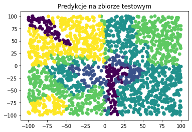

```python
plt.scatter(X1[:, 0], X1[:, 1], c = np.apply_along_axis(p, 1, n3_m1.forward(X1)).argmax(axis=1))
plt.title('Predykcje na zbiorze testowym')
plt.show()
```

```python
print(f"F1-score-macro na zbiorze testowym wynosi: {f1_score_macro(Y1, np.apply_along_axis(p, 1, n3_m1.forward(X1)))}")
```

```
F1-score-macro na zbiorze testowym wynosi: 0.5543689997847865
```

```python
n3_m1.train(X, Y, X1, Y1, n_epochs=500, eval_frequency=100)
```

```
Epoch: 0, cross-entropy train: 0.843712179555165, cross-entropy eval: 0.89696100707329
Epoch: 100, cross-entropy train: 0.8653119450771346, cross-entropy eval: 0.9226448237489945
Epoch: 200, cross-entropy train: 0.8430992384888208, cross-entropy eval: 0.8751640901092307
Epoch: 300, cross-entropy train: 0.7955406209042479, cross-entropy eval: 0.8340211017428901
Epoch: 400, cross-entropy train: 0.8315415401117402, cross-entropy eval: 0.902968795004003
Training result:
    cross-entropy train: 0.9363887296833796
    cross-entropy eval: 0.9461840301811816
```

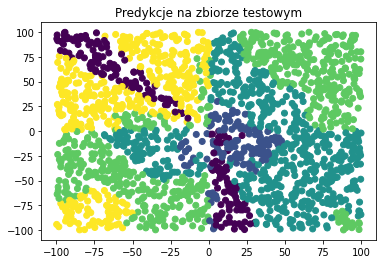

```python
plt.scatter(X1[:, 0], X1[:, 1], c = np.apply_along_axis(p, 1, n3_m1.forward(X1)).argmax(axis=1))
plt.title('Predykcje na zbiorze testowym')
plt.show()
```

```python
print(f"F1-score-macro na zbiorze testowym wynosi: {f1_score_macro(Y1, np.apply_along_axis(p, 1, n3_m1.forward(X1)))}")
```

```
F1-score-macro na zbiorze testowym wynosi: 0.5020737145147068
```

```python
n3_m1.train(X, Y, X1, Y1, n_epochs=500, eval_frequency=100)
```

```
Epoch: 0, cross-entropy train: 0.9400126849581848, cross-entropy eval: 0.9474493169505763
Epoch: 100, cross-entropy train: 0.7475225233654142, cross-entropy eval: 0.7817038252047154
Epoch: 200, cross-entropy train: 0.6995848276128062, cross-entropy eval: 0.7626588999595303
Epoch: 300, cross-entropy train: 0.7438513772912193, cross-entropy eval: 0.8273259515523753
Epoch: 400, cross-entropy train: 0.8541307329296249, cross-entropy eval: 0.927426372837447
Training result:
    cross-entropy train: 0.7357471710217165
    cross-entropy eval: 0.826052618830291
```

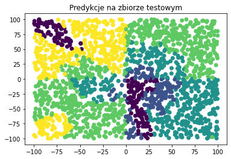

```python
plt.scatter(X1[:, 0], X1[:, 1], c = np.apply_along_axis(p, 1, n3_m1.forward(X1)).argmax(axis=1))
plt.title('Predykcje na zbiorze testowym')
plt.show()
```

```python
print(f"F1-score-macro na zbiorze testowym wynosi: {f1_score_macro(Y1, np.apply_along_axis(p, 1, n3_m1.forward(X1)))}")
```

```
F1-score-macro na zbiorze testowym wynosi: 0.5886150290780349
```

```python
n3_m1.train(X, Y, X1, Y1, n_epochs=500, eval_frequency=100)
```

```
Epoch: 0, cross-entropy train: 0.7362744724692397, cross-entropy eval: 0.826894092222229
Epoch: 100, cross-entropy train: 0.8816903254875853, cross-entropy eval: 0.9558892473222746
Epoch: 200, cross-entropy train: 0.8201631889637616, cross-entropy eval: 0.9231590630777547
Epoch: 300, cross-entropy train: 0.7652941932151461, cross-entropy eval: 0.8663174997194717
Epoch: 400, cross-entropy train: 0.9370697968225524, cross-entropy eval: 1.021070027776964
Training result:
    cross-entropy train: 0.7971111870998823
    cross-entropy eval: 0.8699835340392482
```

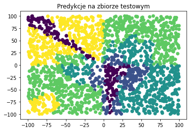

```python
plt.scatter(X1[:, 0], X1[:, 1], c = np.apply_along_axis(p, 1, n3_m1.forward(X1)).argmax(axis=1))
plt.title('Predykcje na zbiorze testowym')
plt.show()
```

Dalszy trening prowadzi do wzrostu wartości funkcji aktywacji

### Funkcja aktywacji ReLU

```python
np.random.seed(0)
n3_m2 = Net(optimizer = GradientDescentBatch(learning_rate=0.0001, batch_size=64), loss = 'cross-entropy')
n3_m2.add_layer(DenseNetLayer(2, 50, ReLU(), XavierInitializer(2, 50)))
n3_m2.add_layer(DenseNetLayer(50, 50, ReLU(), XavierInitializer(50, 50)))
n3_m2.add_layer(DenseNetLayer(50, 20, ReLU(), XavierInitializer(50, 20)))
n3_m2.add_layer(DenseNetLayer(20, 5, SoftmaxAsLastLayerWithCrossEntropy(), XavierInitializer(20, 5)))
n3_m2.train(X, Y, X1, Y1, n_epochs=500, eval_frequency=100)
```

```
Epoch: 0, cross-entropy train: 5.022678697220741, cross-entropy eval: 6.716414263222413
Epoch: 100, cross-entropy train: 1.1141109018572077, cross-entropy eval: 1.2260372344686261
Epoch: 200, cross-entropy train: 1.0809557268901249, cross-entropy eval: 1.262218961167833
Epoch: 300, cross-entropy train: 0.9957010832323762, cross-entropy eval: 1.1601700751572286
Epoch: 400, cross-entropy train: 0.9629455166430736, cross-entropy eval: 1.1229695514687708
Training result:
    cross-entropy train: 0.9533526881689142
    cross-entropy eval: 1.1131045433593103
```

```python
print(f"F1-score-macro na zbiorze testowym wynosi: {f1_score_macro(Y1, np.apply_along_axis(p, 1, n3_m2.forward(X1)))}")
```

```
F1-score-macro na zbiorze testowym wynosi: 0.4767256634791336
```

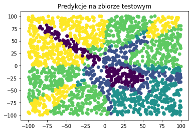

```python
plt.scatter(X1[:, 0], X1[:, 1], c = np.apply_along_axis(p, 1, n3_m2.forward(X1)).argmax(axis=1))
plt.title('Predykcje na zbiorze testowym')
plt.show()
```

```python
n3_m2.train(X, Y, X1, Y1, n_epochs=500, eval_frequency=100)
```

```
Epoch: 0, cross-entropy train: 0.9549588008522917, cross-entropy eval: 1.1169575480626712
Epoch: 100, cross-entropy train: 0.9559884658619175, cross-entropy eval: 1.1326082534933273
Epoch: 200, cross-entropy train: 0.9885215837391599, cross-entropy eval: 1.1937675033506112
Epoch: 300, cross-entropy train: 0.9503201994422575, cross-entropy eval: 1.1365915501068817
Epoch: 400, cross-entropy train: 0.9672221205008471, cross-entropy eval: 1.1548452077894358
Training result:
    cross-entropy train: 1.0357273781762701
    cross-entropy eval: 1.1864241907245971
```

```python
save_model(n3_m2, 'n3_m2_b_2')
```

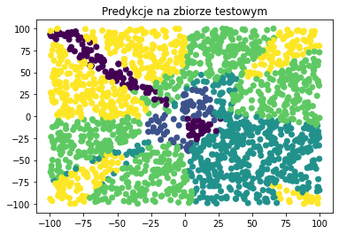

```python
plt.scatter(X1[:, 0], X1[:, 1], c = np.apply_along_axis(p, 1, n3_m2.forward(X1)).argmax(axis=1))
plt.title('Predykcje na zbiorze testowym')
plt.show()
```

```python
print(f"F1-score-macro na zbiorze testowym wynosi: {f1_score_macro(Y1, np.apply_along_axis(p, 1, n3_m2.forward(X1)))}")
```

```
F1-score-macro na zbiorze testowym wynosi: 0.43194351385133845
```

Dalszy trening tylko pogarsza wynik na zbiorze testowym

# PODSUMOWANIE

Uzyskane wyniki są widoczne w tabeli:

[output not shown]

Jak widać w tabeli powyżej, najlepiej radziły sobie sieci z większą liczbą warstw ukrytych. Sieci dla zbioru multimodal-large z jedną warstwą ukrytą de facto nic się nie nauczyły.

Najgorzej radziła sobie liniowa funkcja aktywacji - jest ona zbyt prosta w stosunku do rozważanych problemów.

Z tabeli widać również, że zmiana funkcji aktywacji może znacząco przyspieszyć proces uczenia, np. multimodal-large z ReLU z dwiema warstwami ukrytymi miał wynik 15.4 po 500 epokach, podczas gdy sieć z Tanh miała już wynik 1.79.

Z drugiej strony, porównując historie uczenia dla zadań klasyfikacji, sieci z funkcją ReLU osiągały szybciej lepsze wyniki.